# BCB420 Assignment 2: Data set Pathway and Network Analysis

Arhan Rupani

2026-03-12

# 1 Brief introduction

Acute Myloid Leukemia (AML) is a heterogeneous disease where different cell types contribute in disparate ways towards cancer initiation and progression. Therefore, to understand the biology of the disease, one needs to study it at the most microscopic level possible. In light of this and owing to my interest in cancer systems biology, I have chosen a case-control single cell RNAseq (scRNAseq) dataset of AML (Galen et al. 2019).

The dataset contains bone marrow cells, from 5 healthy donors and 16 AML patients. Hence our control condition represents healthy hematopoeisis (healthy blood formation), and our test condition is that of malignant hematopoeisis (i.e. blood formation in AML). Given the scope of this assignment, I have decided to include the following in my dataset: all healthy cells and only a single AML patient’s cells.

More detail on background, data inspection, and differential gene expression analysis can be found in report 1 below.

# 2 Assignment 1

## 2.1 Introduction

A note on the structure of this r markdown report: firstly, chunks of code which do not substantially reflect any specific learning are left out of the render however rmarkdown should be checked to understand the full extent of the work put into the assignment; then there are code chunks for which outputs are ommited but the code is shown to highlight the code itself. Finally, there are code chunks for which outputs are displayed and are meant to be read as a part of the report.

### 2.1.1 Dataset description

The dataset contains bone marrow cells, from 5 healthy donors and 16 AML patients. Hence our control condition represents healthy hematopoeisis (healthy blood formation), and our test condition is that of malignant hematopoeisis (i.e. blood formation in AML). Given the scope of this assignment, I have decided to include the following in my dataset: all healthy cells and only a single AML patient’s cells.

#### 2.1.1.1 Dataset downloading

First we start with installing our dataset. Here I have written part of my routine in bash as GEOquery wasn’t working well for single cell data.

```bash
## Set initial directory

cd /home/rstudio/projects
```

```r
## Do the string processing for links in R and save it in a text file

## healthy string processing
if (!"healthy_data_links.txt" %in% list.files("/home/rstudio/projects")) {
  healthy_samp_num_vector <- paste0("GSM358", 7996:8003)
  ftp_links <- paste0("ftp://ftp.ncbi.nlm.nih.gov/geo/samples/", substring(healthy_samp_num_vector, 1, 7), "nnn/", healthy_samp_num_vector, "/suppl/")
  writeLines(ftp_links, "healthy_data_links.txt")
}

## cancer string processing
if (!"cancer_data_links.txt" %in% list.files("/home/rstudio/projects")) {
  cancer_sample_num_vector <- paste0("GSM358", 7963:7968)
ftp_links <- paste0("ftp://ftp.ncbi.nlm.nih.gov/geo/samples/", substring(cancer_sample_num_vector, 1, 7), "nnn/", cancer_sample_num_vector, "/suppl/")
writeLines(ftp_links, "cancer_data_links.txt")
}
```

```bash
## Set up the data directories, download the files, and unzip them

## TODO: put this in an ifelse block
if [ ! -d "data/healthy" ] || [ ! -d "data/cancer" ]; then
    echo Setting up the data directories...
    mkdir data && mkdir data/healthy data/cancer

    echo Downloading files..
    while IFS= read -r url; do
        echo "Downloading from: $url"
        wget -nc -P /home/rstudio/projects/data/healthy -r -nH --cut-dirs=6 --no-parent "$url"
    done < healthy_data_links.txt

    while IFS= read -r url; do
        echo "Downloading from: $url"
        wget -nc -P /home/rstudio/projects/data/cancer -r -nH --cut-dirs=6 --no-parent "$url"
    done < cancer_data_links.txt

    echo Done downloading the files!

    # Unzip the files
    cd /home/rstudio/projects/data/healthy
    gunzip *.gz

    cd /home/rstudio/projects/data/cancer
    gunzip *.gz

    cd /home/rstudio/projects
else
    echo "Data directories already exist. Skipping download."
fi
```

```
## Data directories already exist. Skipping download.
```

#### 2.1.1.2 Dataset loading

```r
## Read all the files into apprpriate seurat objects and put them into their respective case and control lists

## Function to read in the count matrices
read_counts <- function(file) {
  x <- readr::read_tsv(file)
  x <- as.data.frame(x)
  genes <- x$Gene
  x <- x[, -1]
  rownames(x) <- genes
  return(as.matrix(x))
}

## Function to read in metadata
read_meta <- function(file) {
  y <- readr::read_tsv(file)
  y <- as.data.frame(y)
  cells <- y$Cell
  y <- y[, -1]
  rownames(y) <- cells
  return(y)
}

##1. Healthy data preparation

### I am hard coding the paths but ideally you want to use getwd()
counts_files <- list.files("/home/rstudio/projects/data/healthy", pattern = "*.dem.txt", full.names = TRUE)
meta_files <- list.files("/home/rstudio/projects/data/healthy", pattern = "*.anno.txt", full.names = TRUE)
healthy_samp_names <- str_extract(counts_files, "BM[^.]+")

counts <- purrr::map(counts_files, read_counts)
meta <- purrr::map(meta_files, read_meta)

### Create seurat object
healthy_objs <- purrr::map2(counts, meta, ~ SeuratObject::CreateSeuratObject(counts = as(.x, "sparseMatrix"), meta.data = .y))
names(healthy_objs) <- healthy_samp_names


##2. AML data preparation
counts_files <- list.files("/home/rstudio/projects/data/cancer", pattern = "*.dem.txt", full.names = TRUE)
meta_files <- list.files("/home/rstudio/projects/data/cancer", pattern = "*.anno.txt", full.names = TRUE)
cancer_samp_names <- str_extract(counts_files, "AML[^.]+")

counts <- purrr::map(counts_files, read_counts)
meta <- purrr::map(meta_files, read_meta)

## Create seurat object
cancer_objs <- purrr::map2(counts, meta, ~ SeuratObject::CreateSeuratObject(counts = as(.x, "sparseMatrix"), meta.data = .y))
names(cancer_objs) <- cancer_samp_names

rm(counts)
rm(meta)
gc()

## There are two lists of containing seurat objects: healthy and cancer
## healthy_objs and cancer_objs
```

```r
## combine the objects appropriately and show cell types

healthy_merg_seurat <- purrr::reduce(healthy_objs, merge)
hdata <- healthy_merg_seurat
hdata$condition <- "healthy"

## names(hdata@assays$RNA@layers) <- names(healthy_objs)
## Dont change the layer names, causes internal conflicts because of the oop (no setter available)

cancer_merg_seurat<- purrr::reduce(cancer_objs, merge)
cdata <- cancer_merg_seurat
cdata$condition <- "cancer"

rm(cancer_objs)
rm(cancer_merg_seurat)
rm(healthy_merg_seurat)
rm(healthy_objs)
gc()
```

### 2.1.2 Exploratory Analysis

Overall, below are the total number of cells from each condition used for the downstream purposes of this assignment.

```
## Cells in healthy sample: 7698
```

```
## Cells in AML sample: 4982
```

The authors have supplied their annotations of cell types for all the cells and so we will use their cell type annotations for the analysis. Here below are the bar plots depicting counts of cell types in each condition.

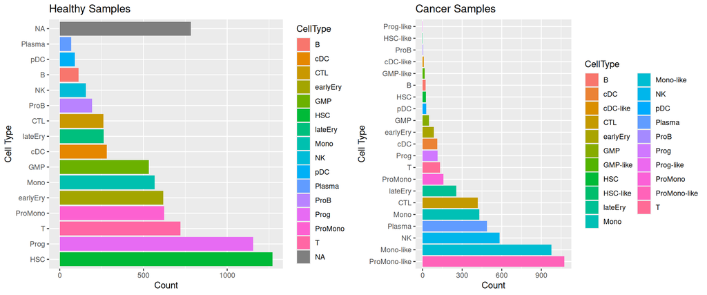

```r
p1 <- ggplot(hdata[[]], aes(x = fct_infreq(CellType), fill = CellType)) +
  geom_bar() + coord_flip() +
  labs(title = "Healthy Samples", x = "Cell Type", y = "Count")

p2 <- ggplot(cdata[[]], aes(x = fct_infreq(CellType), fill = CellType)) +
  geom_bar() + coord_flip() +
  labs(title = "Cancer Samples", x = "Cell Type", y = "Count")

grid.arrange(p1, p2, ncol = 2)
```

### 2.1.3 Experiment Hypotheis

Following exploratory analysis of the dataset, I found that that the most abundant cell type in the AML pateint sample was Pro-Monocytes. Therefore we are interested in studying gene expression changes in particularly pro-monocytes in healthy hematopoeisis vs malignant hematopoesis.

This is also interesting because we are studying AML, which is a malignancy of myeloid cells, and pro-monocytes are a part of the myeloid lineage

## 2.2 Analysis

```r
##1. merge healthy data with cancer
case_cont_data <- merge(hdata, cdata)

##2. Add a metadata column that specifies info about celltype + condition
case_cont_data[[]]["CellType-condition"] <- paste0(case_cont_data$CellType, "-", case_cont_data$condition)
Idents(case_cont_data) <- 'CellType-condition'
```

```
## Total genes in our dataset: 27899
```

### 2.2.1 Gene identifier mapping

NOTE: Coding help from Gen.AI was seeked to figure out to how fetch data from different mirrors while being able to catch any errors in connecting to the mart itslef and during the retrival of information.

```r
## Check mapping of all genes to HUGO symbols
## Get all gene names from the dataset
all_genes <- Features(case_cont_data)
cat("Total genes in dataset:", length(all_genes), "\n\n")
```

```
## Total genes in dataset: 27899
```

```r
## Connect to biomaRt with error handling
library(biomaRt)

## Increase timeout
options(timeout = 300)

## Try to connect to biomaRt with fallback mirrors
mart <- NULL
mirrors <- c(
  "https://asia.ensembl.org",
  "https://useast.ensembl.org",
  "https://www.ensembl.org"
)

for (mirror in mirrors) {
  cat("Attempting to connect to:", mirror, "\n")
  tryCatch({
    mart <- useMart("ensembl",
                    dataset = "hsapiens_gene_ensembl",
                    host = mirror)
    cat("Successfully connected to:", mirror, "\n\n")
    break
  }, error = function(e) {
    cat("Failed to connect to", mirror, ":", e$message, "\n")
  })
}
```

```
## Attempting to connect to: https://asia.ensembl.org
## Failed to connect to https://asia.ensembl.org : HTTP 403 Forbidden.
## Attempting to connect to: https://useast.ensembl.org
## Successfully connected to: https://useast.ensembl.org
```

```r
if (is.null(mart)) {
  stop("Failed to connect to any Ensembl mirror. Please check your internet connection and try again later.")
}

## Query all genes with error handling and retry logic
chunk_size <- 5000
n_chunks <- ceiling(length(all_genes) / chunk_size)
all_results <- list()
failed_chunks <- c()

for (i in 1:n_chunks) {
  start_idx <- (i - 1) * chunk_size + 1
  end_idx <- min(i * chunk_size, length(all_genes))

  cat("Processing chunk", i, "of", n_chunks,
      "(genes", start_idx, "to", end_idx, ")...\n")

  chunk_genes <- all_genes[start_idx:end_idx]

  # Retry logic
  max_attempts <- 3
  attempt <- 1
  success <- FALSE
  chunk_results <- NULL

  while (attempt <= max_attempts && !success) {
    tryCatch({
      chunk_results <- getBM(
        attributes = c('hgnc_symbol', 'external_gene_name', 'gene_biotype'),
        filters = 'hgnc_symbol',
        values = chunk_genes,
        mart = mart
      )
      all_results[[i]] <- chunk_results
      success <- TRUE
      cat("  ✓ Chunk", i, "completed successfully\n")
    }, error = function(e) {
      cat("  ✗ Attempt", attempt, "failed:", conditionMessage(e), "\n")
      if (attempt < max_attempts) {
        wait_time <- attempt * 5  # Increasing wait time
        cat("  Waiting", wait_time, "seconds before retry...\n")
        Sys.sleep(wait_time)
      }
      attempt <<- attempt + 1
    })
  }

  if (!success) {
    cat("  ⚠ WARNING: Chunk", i, "failed after", max_attempts, "attempts\n")
    failed_chunks <- c(failed_chunks, i)
    all_results[[i]] <- data.frame()  # Empty data frame as placeholder
  }

  # Delay between successful chunks to avoid overwhelming server
  if (success && i < n_chunks) {
    Sys.sleep(2)
  }
}
```

```
## Processing chunk 1 of 6 (genes 1 to 5000 )...
##   ✓ Chunk 1 completed successfully
## Processing chunk 2 of 6 (genes 5001 to 10000 )...
##   ✓ Chunk 2 completed successfully
## Processing chunk 3 of 6 (genes 10001 to 15000 )...
##   ✓ Chunk 3 completed successfully
## Processing chunk 4 of 6 (genes 15001 to 20000 )...
##   ✓ Chunk 4 completed successfully
## Processing chunk 5 of 6 (genes 20001 to 25000 )...
##   ✓ Chunk 5 completed successfully
## Processing chunk 6 of 6 (genes 25001 to 27899 )...
##   ✓ Chunk 6 completed successfully
```

```r
## Report on failed chunks
if (length(failed_chunks) > 0) {
  cat("\n⚠ WARNING: The following chunks failed to download:\n")
  cat("Chunks:", paste(failed_chunks, collapse = ", "), "\n")
  cat("This affects genes",
      paste((failed_chunks - 1) * chunk_size + 1, "to",
            pmin(failed_chunks * chunk_size, length(all_genes)),
            collapse = "; "), "\n\n")
}

## Combine all results, filtering out empty data frames
all_results <- all_results[sapply(all_results, nrow) > 0]

if (length(all_results) == 0) {
  stop("No data was successfully retrieved from biomaRt. Please check your connection and try again.")
}

mapped_genes <- tryCatch({
  do.call(rbind, all_results)
}, error = function(e) {
  cat("Error combining results:", e$message, "\n")
  data.frame(hgnc_symbol = character(),
             external_gene_name = character(),
             gene_biotype = character())
})

## Analysis of mapping results
cat("\n=== MAPPING RESULTS ===\n")
```

```
##
## === MAPPING RESULTS ===
```

```r
cat("Total genes queried:", length(all_genes), "\n")
```

```
## Total genes queried: 27899
```

```r
cat("Successfully mapped:", nrow(mapped_genes), "\n")
```

```
## Successfully mapped: 24613
```

```r
if (length(all_genes) > 0) {
  cat("Match rate:", round(nrow(mapped_genes)/length(all_genes)*100, 2), "%\n\n")
} else {
  cat("Match rate: N/A (no genes to query)\n\n")
}
```

```
## Match rate: 88.22 %
```

```r
## Identify unmapped genes
unmapped_genes <- setdiff(all_genes, mapped_genes$hgnc_symbol)
cat("Unmapped genes:", length(unmapped_genes), "\n")
```

```
## Unmapped genes: 3494
```

```r
## Show examples of unmapped genes
if (length(unmapped_genes) > 0) {
  cat("\nFirst 20 unmapped genes:\n")
  print(head(unmapped_genes, 20))

  # Save unmapped genes to file for manual inspection
  tryCatch({
    write.csv(data.frame(Gene = unmapped_genes),
              "unmapped_genes.csv",
              row.names = FALSE)
    cat("\nFull list of unmapped genes saved to: unmapped_genes.csv\n")
  }, error = function(e) {
    cat("\nWarning: Could not save unmapped genes to file:", e$message, "\n")
  })
}
```

```
##
## First 20 unmapped genes:
##  [1] "AA06"            "AAED1"           "AARS"            "AATK-AS1"
##  [5] "ABHD11-AS1"      "ACBD7-DCLRE1CP1" "ACPP"            "ACPT"
##  [9] "ACTN1-AS1"       "ADAL"            "ADGRF2"          "ADPRHL2"
## [13] "ADSS"            "ADSSL1"          "AES"             "AFDN-AS1"
## [17] "AFF1-AS1"        "AGPAT4-IT1"      "AHSA2"           "AKAP2"
##
## Full list of unmapped genes saved to: unmapped_genes.csv
```

```
##
## === GENE BIOTYPES ===
##
##                          IG_V_gene                    IG_V_pseudogene
##                                  1                                  1
##                             lncRNA                              miRNA
##                               3008                               1850
##                           misc_RNA               processed_pseudogene
##                                  7                                112
##                     protein_coding                           ribozyme
##                              18437                                  2
##                             scaRNA                             snoRNA
##                                 19                                434
##                              snRNA                                TEC
##                                 34                                  6
##   transcribed_processed_pseudogene     transcribed_unitary_pseudogene
##                                122                                 65
## transcribed_unprocessed_pseudogene                 unitary_pseudogene
##                                444                                  3
##             unprocessed_pseudogene                          vault_RNA
##                                 64                                  4
```

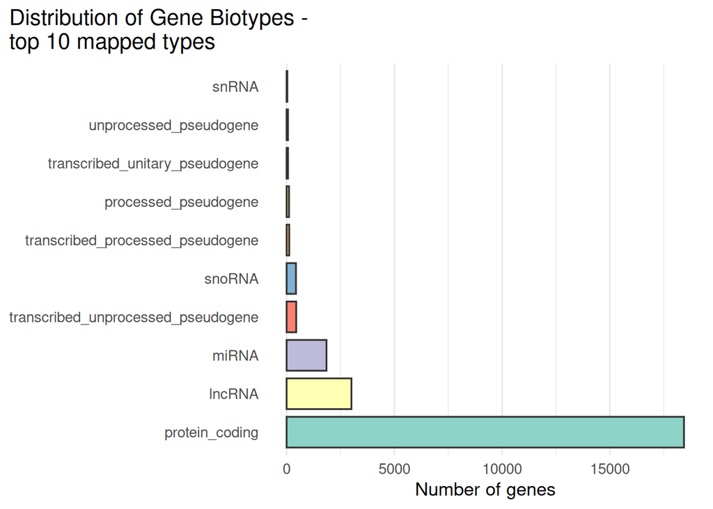

```r
## Check for gene biotypes
if (nrow(mapped_genes) > 0) {
  cat("\n=== GENE BIOTYPES ===\n")
  biotype_summary <- table(mapped_genes$gene_biotype)
  print(biotype_summary)

  # Create bar plot for mapped gene biotypes
  tryCatch({
    # Convert biotype table to data.frame
    biotype_tab <- table(mapped_genes$gene_biotype)
    df_biotypes <- data.frame(
      biotype = names(biotype_tab),
      n       = as.integer(biotype_tab),
      stringsAsFactors = FALSE
    )

    # Order by counts (descending) and take top 10
    df_biotypes <- df_biotypes[order(df_biotypes$n, decreasing = TRUE), ]
    df_biotypes <- df_biotypes[1:min(10, nrow(df_biotypes)), ]
    df_biotypes$biotype <- factor(df_biotypes$biotype, levels = df_biotypes$biotype)

    # Create the plot
    print(
      ggplot(df_biotypes, aes(x = biotype, y = n, fill = biotype)) +
        geom_col(width = 0.8, color = "grey20") +
        coord_flip() +
        scale_fill_brewer(palette = "Set3", guide = "none") +
        labs(
          x = NULL, y = "Number of genes",
          title = "Distribution of Gene Biotypes - \ntop 10 mapped types"
        ) +
        theme_minimal(base_size = 13) +
        theme(
          plot.title.position = "plot",
          panel.grid.major.y = element_blank()
        )
    )
  }, error = function(e) {
    cat("\nWarning: Could not create biotype plot:", e$message, "\n")
  })
} else {
  cat("\n⚠ No genes were successfully mapped. Cannot generate biotype summary.\n")
}
```

```r
## Check for duplicate mappings (genes that map to multiple symbols)
duplicated_genes <- all_genes[duplicated(all_genes)]
if (length(duplicated_genes) > 0) {
  cat("\n=== DUPLICATE GENES ===\n")
  cat("Duplicate gene names found:", length(duplicated_genes), "\n")
  print(head(duplicated_genes, 20))
}

## Summary
cat("\n=== SUMMARY ===\n")
```

```
##
## === SUMMARY ===
```

```r
if (length(all_genes) > 0 && nrow(mapped_genes) > 0) {
  match_rate <- nrow(mapped_genes) / length(all_genes)
  cat("Gene names appear to be",
      ifelse(match_rate > 0.95,
             "HUGO symbols",
             "NOT standard HUGO symbols"), "\n")

  if (length(failed_chunks) > 0) {
    cat("\n⚠ Note: Some chunks failed to download. Results may be incomplete.\n")
    cat("Consider re-running the failed chunks manually.\n")
  }
} else {
  cat("⚠ Unable to determine gene symbol type due to insufficient data.\n")
}
```

```
## Gene names appear to be NOT standard HUGO symbols
```

```
##
## === ANALYZING UNMAPPED GENES ===
```

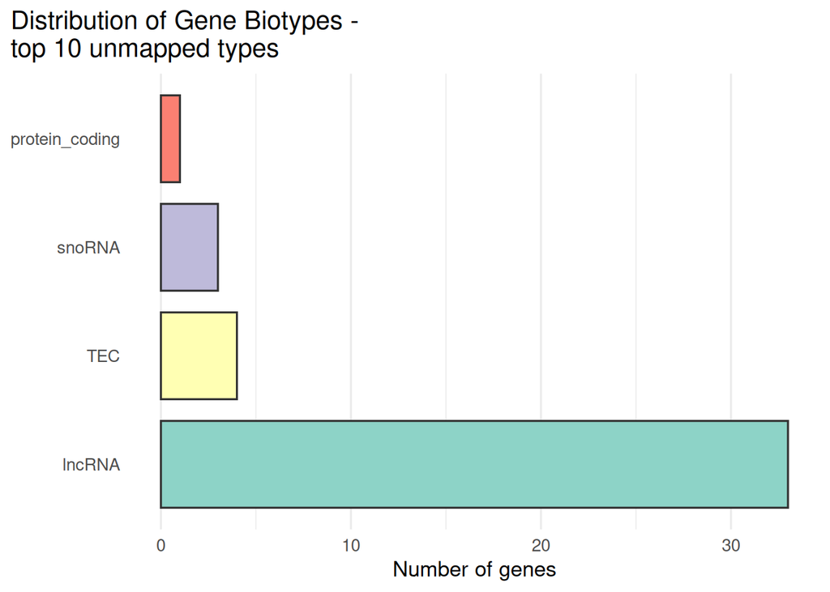

```r
## Create bar plot for UNMAPPED gene biotypes
if (length(unmapped_genes) > 0) {
  cat("\n=== ANALYZING UNMAPPED GENES ===\n")

  # Query biomaRt for unmapped genes to get their biotypes
  # These might be outdated symbols, non-coding genes, etc.
  unmapped_biotypes <- tryCatch({
    getBM(
      attributes = c('hgnc_symbol', 'external_gene_name', 'gene_biotype'),
      filters = 'external_gene_name',  # Try external_gene_name instead
      values = unmapped_genes,
      mart = mart
    )
  }, error = function(e) {
    cat("Could not retrieve biotype info for unmapped genes:", e$message, "\n")
    data.frame(hgnc_symbol = character(),
               external_gene_name = character(),
               gene_biotype = character())
  })

  if (nrow(unmapped_biotypes) > 0) {
    # Convert biotype table to data.frame
    biotype_tab <- table(unmapped_biotypes$gene_biotype)
    df_biotypes_unmapped <- data.frame(
      biotype = names(biotype_tab),
      n       = as.integer(biotype_tab),
      stringsAsFactors = FALSE
    )

    # Order by counts (descending) and take top 10
    df_biotypes_unmapped <- df_biotypes_unmapped[order(df_biotypes_unmapped$n, decreasing = TRUE), ]
    df_biotypes_unmapped <- df_biotypes_unmapped[1:min(10, nrow(df_biotypes_unmapped)), ]
    df_biotypes_unmapped$biotype <- factor(df_biotypes_unmapped$biotype,
                                           levels = df_biotypes_unmapped$biotype)

    # Create the plot
    print(
      ggplot(df_biotypes_unmapped, aes(x = biotype, y = n, fill = biotype)) +
        geom_col(width = 0.8, color = "grey20") +
        coord_flip() +
        scale_fill_brewer(palette = "Set3", guide = "none") +
        labs(
          x = NULL, y = "Number of genes",
          title = "Distribution of Gene Biotypes - \ntop 10 unmapped types"
        ) +
        theme_minimal(base_size = 13) +
        theme(
          plot.title.position = "plot",
          panel.grid.major.y = element_blank()
        )
    )
  } else {
    cat("Could not retrieve biotype information for unmapped genes.\n")
    cat("These genes may be:\n")
    cat("  - Outdated gene symbols\n")
    cat("  - Non-standard nomenclature\n")
    cat("  - Mitochondrial genes (MT-*)\n")
    cat("  - Pseudogenes or withdrawn symbols\n")
  }
} else {
  cat("\nNo unmapped genes to analyze.\n")
}
```

Above is a barplot of biotypes of unmapped genes for which biotype information was available.

#### 2.2.1.1 Handling of duplicate gene mappings

No duplicate gene symbols were detected in this dataset, we explicitely check for it in the code.

#### 2.2.1.2 Handling of unmapped genes

- **Total unmapped**: 3494
- **Approach**: These genes were analyzed for their biotype distribution (shown in bar plot above)
- **Decision**: Unmapped genes were retained in the Seurat object for completeness but are clearly identified and can be filtered if needed for specific analyses

### 2.2.2 Normalization

#### 2.2.2.1 Rationale for normalization method

1. Normalizes gene expression measurements for each cell by the total expression
2. Multiplies by a scale factor (10,000 by default)
3. Log-transforms the result (natural log)

```r
case_cont_data <- NormalizeData(case_cont_data)
```

To assess the effectiveness of normalization, I compared the distribution of total counts per cell before and after normalization.

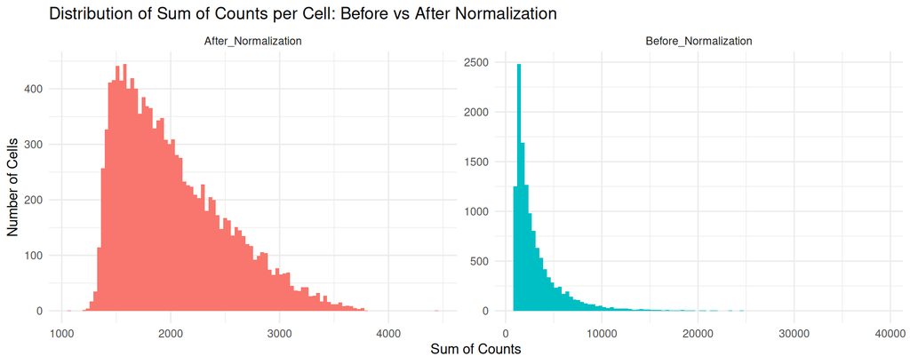

```r
## Join layers first
case_cont_data <- JoinLayers(case_cont_data)

## Extract sum of counts for each cell
counts_before <- colSums(LayerData(case_cont_data, assay = "RNA", layer = "counts"))
counts_after <- colSums(LayerData(case_cont_data, assay = "RNA", layer = "data"))

## Create comparison dataframe
comparison_df <- data.frame(
  Before_Normalization = counts_before,
  After_Normalization = counts_after
)

## Reshape to long format
comparison_long <- pivot_longer(comparison_df,
                                 cols = c("Before_Normalization", "After_Normalization"),
                                 names_to = "Stage",
                                 values_to = "Sum_Counts")

## Create histogram
ggplot(comparison_long, aes(x = Sum_Counts, fill = Stage)) +
  geom_histogram(bins = 100) +
  facet_wrap(~Stage, scales = "free") +
  theme_minimal() +
  labs(
    title = "Distribution of Sum of Counts per Cell: Before vs After Normalization",
    x = "Sum of Counts",
    y = "Number of Cells"
  ) +
  theme(legend.position = "none")
```

**Interpretation**: The before normalization histogram shows the raw count distribution with high cell-to-cell variability in total counts, reflecting technical variation in sequencing depth. After LogNormalize, the data is log-transformed and scaled, which compresses the range and centers the distribution. This normalization step is crucial for making cells comparable accounting for variable sequencing depths for each cell.

**Note on final dataset format**: While the assignment specifies producing a dataframe with HUGO symbols as rownames and samples as columns, single-cell data is inherently different from bulk RNA-seq. In scRNA-seq, each “sample” is a single cell (12,680 cells in our case), making a traditional gene × sample matrix impractical. Instead, I have retained the data in a Seurat object format, which efficiently stores: - Gene expression matrix (genes × cells) - Cell metadata (condition, cell type, etc.) - Normalized data in separate layers

### 2.2.3 Differential Gene Expression

#### 2.2.3.1 Model design

First I run the basic pipeline to fully process the single-cell data, this includes finding top variable genes, performing principle component analysis, unsepervised clustering (not needed here though), and umap visualization. Finally then, I ask what genes are differentially upregulates/downregulated in different conditions for cells of the same type.

```r
## Identify differential expressed genes across conditions

##3. Run Pipeline
case_cont_data <- FindVariableFeatures(case_cont_data)
```

```
## Finding variable features for layer counts
```

```r
case_cont_data <- ScaleData(case_cont_data)
case_cont_data <- RunPCA(case_cont_data)
```

[output not shown]

```r
case_cont_data <- FindNeighbors(case_cont_data, dims = 1:30, reduction = "pca")
case_cont_data <- FindClusters(case_cont_data, resolution = 2, cluster.name = "unintegrated_clusters")
```

```
## Modularity Optimizer version 1.3.0 by Ludo Waltman and Nees Jan van Eck
##
## Number of nodes: 12680
## Number of edges: 499782
##
## Running Louvain algorithm...
## Maximum modularity in 10 random starts: 0.8206
## Number of communities: 31
## Elapsed time: 1 seconds
```

```r
case_cont_data <- RunUMAP(case_cont_data, dims = 1:30, reduction = "pca", reduction.name = "umap.unintegrated")
```

```r
DimPlot(case_cont_data, reduction = "umap.unintegrated", group.by = c("orig.ident", "unintegrated_clusters", "CellType"))

##3. DGE
case_cont_data[["RNA"]] <- JoinLayers(case_cont_data[["RNA"]])
Idents(case_cont_data) <- 'CellType-condition'
promono.case_cond.response <- FindMarkers(case_cont_data, ident.1 = "ProMono-like-cancer", ident.2 = "ProMono-healthy", verbose = FALSE)
```

[output not shown]

```r
## Get top 5 upregulated genes (positive log2FC = higher in healthy)
top_up <- promono.case_cond.response %>%
  filter(avg_log2FC > 0) %>%
  arrange(p_val_adj) %>%
  head(5)

top_up$Gene <- rownames(top_up)
top_up$Direction <- "Upregulated"
top_up <- top_up[, c("Gene", "avg_log2FC", "p_val_adj", "Direction")]

## Get top 5 downregulated genes (negative log2FC = higher in cancer)
top_down <- promono.case_cond.response %>%
  filter(avg_log2FC < 0) %>%
  arrange(p_val_adj) %>%
  head(5)

top_down$Gene <- rownames(top_down)
top_down$Direction <- "Downregulated"
top_down <- top_down[, c("Gene", "avg_log2FC", "p_val_adj", "Direction")]

## Combine and format
top_genes_table <- rbind(top_up, top_down)
top_genes_table$avg_log2FC <- round(top_genes_table$avg_log2FC, 3)
top_genes_table$p_val_adj <- format(top_genes_table$p_val_adj, scientific = TRUE, digits = 3)

## Rename columns for display
colnames(top_genes_table) <- c("Gene", "Log2 Fold Change", "Adjusted P-value", "Direction")

library(knitr)
kable(top_genes_table,
      align = c('l', 'r', 'r', 'l'),
      row.names = FALSE,
      caption = "Top 5 upregulated and downregulated genes in healthy vs cancer pro-monocytes.")
```

Top 5 upregulated and downregulated genes in healthy vs cancer pro-monocytes.

| Gene | Log2 Fold Change | Adjusted P-value | Direction |
| --- | --- | --- | --- |
| CFD | 3.488 | 6.14e-207 | Upregulated |
| SRGN | 1.731 | 1.07e-201 | Upregulated |
| JUN | 5.353 | 5.79e-173 | Upregulated |
| MARCKS | 4.837 | 7.97e-154 | Upregulated |
| MALAT1 | 1.861 | 1.62e-125 | Upregulated |
| AREG | -8.757 | 2.26e-283 | Downregulated |
| SELL | -3.908 | 1.69e-143 | Downregulated |
| MPO | -1.989 | 3.39e-126 | Downregulated |
| RPL13AP20 | -3.459 | 2.95e-123 | Downregulated |
| TAPT1-AS1 | -2.761 | 1.41e-115 | Downregulated |

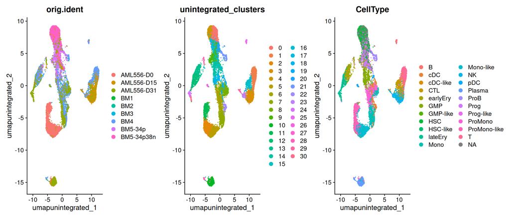

UMAP colored by sample origin, UMAP colored by clusters (resolution = 2.0), UMAP colored by annotated cell type.

#### 2.2.3.2 Volcano plot visualization

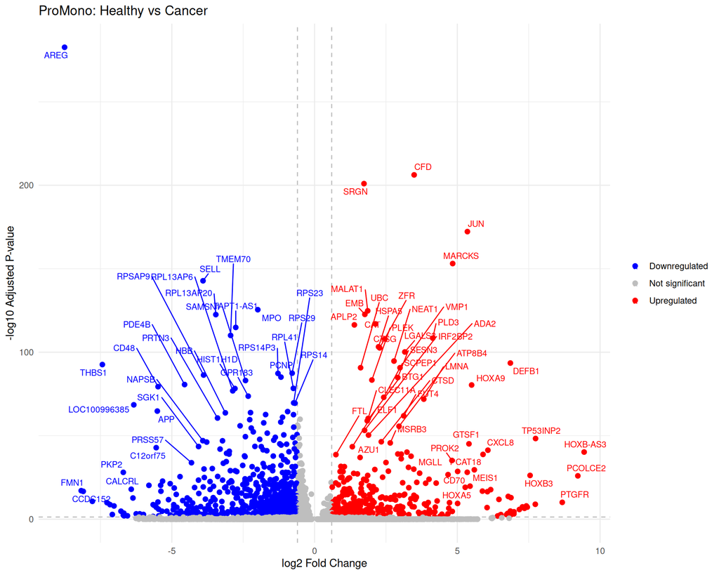

```r
## Visualisation
library(ggplot2)
library(ggrepel)

## Add a column for significance
promono.case_cond.response$gene <- rownames(promono.case_cond.response)
promono.case_cond.response$diffexpressed <- "NO"
promono.case_cond.response$diffexpressed[promono.case_cond.response$avg_log2FC > 0.6 & promono.case_cond.response$p_val_adj < 0.05] <- "UP"
promono.case_cond.response$diffexpressed[promono.case_cond.response$avg_log2FC < -0.6 & promono.case_cond.response$p_val_adj < 0.05] <- "DOWN"

## Label top genes
promono.case_cond.response$delabel <- NA
promono.case_cond.response$delabel[promono.case_cond.response$diffexpressed != "NO"] <- promono.case_cond.response$gene[promono.case_cond.response$diffexpressed != "NO"]

## Plot
ggplot(promono.case_cond.response, aes(x = avg_log2FC, y = -log10(p_val_adj), col = diffexpressed, label = delabel)) +
  geom_vline(xintercept = c(-0.6, 0.6), col = "gray", linetype = 'dashed') +
  geom_hline(yintercept = -log10(0.05), col = "gray", linetype = 'dashed') +
  geom_point(size = 2) +
  scale_color_manual(values = c("blue", "gray", "red"),
                     labels = c("Downregulated", "Not significant", "Upregulated")) +
  geom_text_repel(max.overlaps = 10, size = 3) +
  labs(x = "log2 Fold Change", y = "-log10 Adjusted P-value",
       title = "ProMono: Healthy vs Cancer") +
  theme_minimal() +
  theme(legend.title = element_blank())
```

#### 2.2.3.3 Statistical thresholds and results

**Thresholds used**: - **P-value threshold**: p_val_adj < 0.05 (adjusted p-value using Bonferroni correction) - **Log2 fold change threshold**: |log2FC| > 0.6 (approximately 1.5-fold change)

**Rationale for thresholds**: - **Adjusted p-value < 0.05**: Standard statistical significance threshold after multiple hypothesis correction - **Log2FC > 0.6**: Biological significance threshold captures genes with meaningful expression changes while filtering out minor fluctuations

```r
## Calculate number of significant genes
sig_genes <- promono.case_cond.response[promono.case_cond.response$p_val_adj < 0.05, ]
up_genes <- sig_genes[sig_genes$avg_log2FC > 0.6, ]
down_genes <- sig_genes[sig_genes$avg_log2FC < -0.6, ]

cat("=== DIFFERENTIAL EXPRESSION SUMMARY ===\n")
```

```
## === DIFFERENTIAL EXPRESSION SUMMARY ===
```

```r
cat("Total genes tested:", nrow(promono.case_cond.response), "\n")
```

```
## Total genes tested: 10443
```

```r
cat("Significantly DE genes (p_val_adj < 0.05):", nrow(sig_genes), "\n")
```

```
## Significantly DE genes (p_val_adj < 0.05): 1444
```

```r
cat("Upregulated genes (log2FC > 0.6):", nrow(up_genes), "\n")
```

```
## Upregulated genes (log2FC > 0.6): 387
```

```r
cat("Downregulated genes (log2FC < -0.6):", nrow(down_genes), "\n")
```

```
## Downregulated genes (log2FC < -0.6): 817
```

#### 2.2.3.4 Multiple hypothesis testing correction

**Method used**: Bonferroni correction (default in Seurat’s FindMarkers)

**Why Bonferroni?** Standard in scRNA-seq and Widely accepted in the field. Alternatively we could have also used Benjamini-Hochberg.

#### 2.2.3.5 Heatmap of top differentially expressed genes

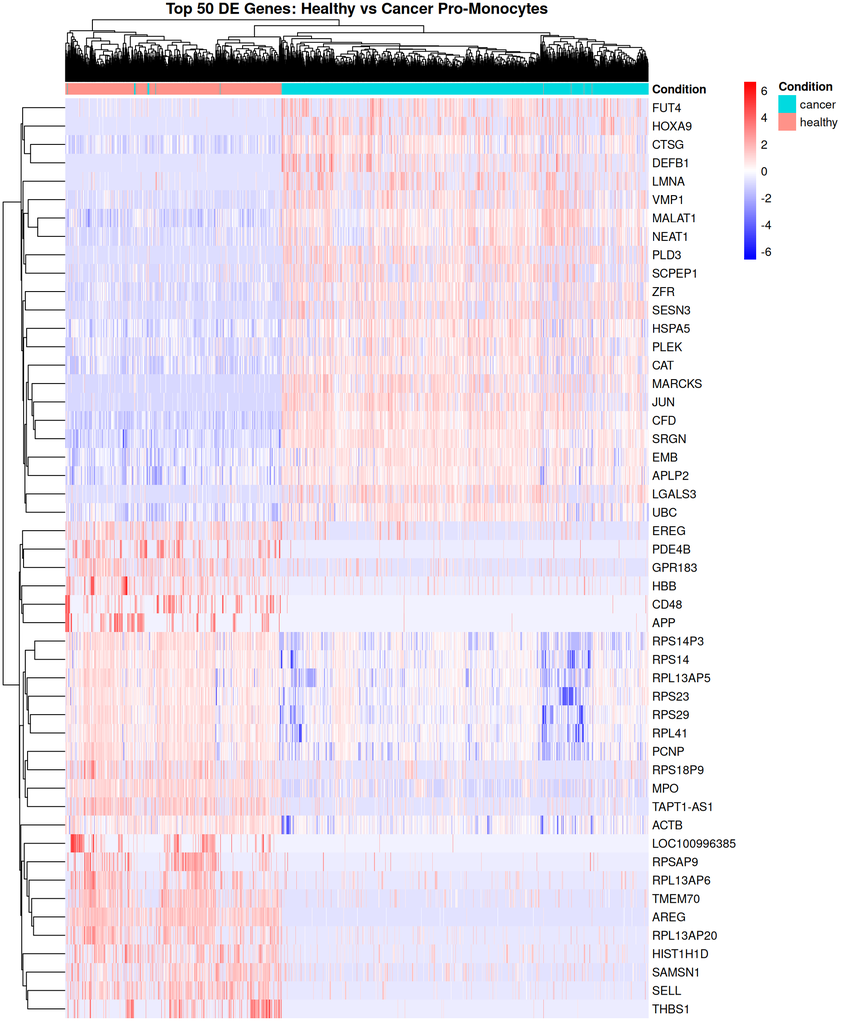

```r
library(pheatmap)
library(pheatmap)

## Get top 50 DE genes (25 up, 25 down)
top_genes <- promono.case_cond.response %>%
  filter(diffexpressed != "NO") %>%
  arrange(p_val_adj) %>%
  head(50) %>%
  rownames()

## Subset Seurat object to pro-monocytes only
promono_cells <- case_cont_data[, case_cont_data$`CellType-condition` %in%
                                   c("ProMono-healthy", "ProMono-like-cancer")]

## Scale the data for these specific genes if not already done
promono_cells <- ScaleData(promono_cells, features = top_genes)

## Extract scaled data for heatmap
heatmap_data <- LayerData(promono_cells, assay = "RNA", layer = "scale.data")[top_genes, ]

## Create annotation for columns (cells)
cell_annotation <- data.frame(
  Condition = promono_cells$condition,
  row.names = colnames(heatmap_data)
)

## Plot heatmap
pheatmap(heatmap_data,
         annotation_col = cell_annotation,
         show_colnames = FALSE,
         show_rownames = TRUE,
         cluster_rows = TRUE,
         cluster_cols = TRUE,
         scale = "none",  # Already scaled
         color = colorRampPalette(c("blue", "white", "red"))(100),
         main = "Top 50 DE Genes: Healthy vs Cancer Pro-Monocytes")
```

**Do conditions cluster together?**

Yes, the heatmap demonstrates clear clustering of cells by condition (healthy vs cancer). This is evident from:

1. **Column clustering**: Cells from the same condition group together, indicating that cancer and healthy pro-monocytes have distinct gene expression profiles
2. **Gene clustering**: Genes cluster into groups that are specifically upregulated or downregulated in one condition

The clear separation validates our differential expression analysis.

#### 2.2.3.6 Final dataset coverage

```
## === FINAL DATASET COVERAGE ===
```

```
## Total genes: 27899
```

```
## Total cells: 12680
```

```
## Healthy cells: 7698
```

```
## Cancer cells: 4982
```

```
## Pro-monocyte cells (healthy): 624
```

```
## Pro-monocyte cells (cancer): 1074
```

## 2.3 Discussion and Conclusion

To summarise, I indeed find patterns of biological organisation, indicated by clear seperation of two conditions, in the heatmap visualisation upon differential gene expression analysis. Remarkably, this suggests that malignant transformation leads to substantial transcriptional reprogramming in pro-monocytes. It would be interesting to further this analysis vy inclusing other patients and looking for ubiquitously dysregulated genes and pathways.

Finally, as the part of this assignment, the following questions needed to be answered. Some have an anchor to the section where they are answered and some are answered below:

- Why is the dataset of interest to you?
- What are the control and test conditions of the dataset?
- How many samples in each of the conditions of your dataset?
- Were there expression values that were not unique for specific genes? How did you handle these?
- Were there expression values that could not be mapped to current HUGO symbols?
- **Were there any outliers in your dataset? How were they handled in the originating paper? How many outliers were removed?**

  **Sample structure**:
  - 5 healthy donors (biological replicates for control condition)
  - 1 AML patient (for test condition)

  **Analysis approach**: Single-cell analysis treats individual cells as technical replicates within biological conditions. Each cell is an independent measurement.

  **Statistical power**: Thousands of cells per condition provide robust statistical power despite having only one AML patient.
- What is the final coverage of your dataset?

NOTE: I have extensively used comments at places in the form of notes within the code, this limits the number of entries I have made in the course journal.

#### 2.3.0.1 For Assignment 2

```r
## save the result of dge analysis
setwd("projects")
promono.case_cond.response["gene"] <- row.names(promono.case_cond.response)
write_csv(promono.case_cond.response, "degList.csv")
```

## 2.4 References

# 3 Assignment 2

```r
setwd("~/projects")
housekeeping <- function(pkg) {
  if (!requireNamespace(pkg, quietly = TRUE)) {
    install.packages(pkg)
  }
  library(pkg, character.only = TRUE)
}

pkgs <- list("ggplot2", "readr", "gprofiler2", "GSA", "dplyr", "RCurl", "knitr")
lapply(pkgs, housekeeping)
```

## 3.1 Thresholded over-representation analysis

### 3.1.1 Creating a thresholded list from the DGE analysis

```r
# reading the gene list
degList <- as.data.frame(read_csv("degList.csv"))
row.names(degList) <- degList[["gene"]]

# thresholding the gene list based on adjusted pvalue
thresholdList <- degList[degList[["p_val_adj"]] < 0.05, ]

# up and down regulated gene sets
upReg <- thresholdList[thresholdList[["avg_log2FC"]] > 0, ]
downReg <- thresholdList[thresholdList[["avg_log2FC"]] < 0, ]

# show top 10 of each
```

### 3.1.2 running g:profiler (Kolberg et al. 2023)

```r
querySet <- thresholdList$gene
organism <- "hsapiens"
gprofilerResults <- gost(
  query = querySet,
  significant = FALSE,
  ordered_query = FALSE,
  exclude_iea = TRUE,
  correction_method = "fdr",
  organism = organism,
  source = c("REAC", "WP", "GO:BP")
)
# get the gprofiler results table
gostplot(gprofilerResults, capped = TRUE, interactive = TRUE)
```

[interactive chart not shown]

```r
enrichment_results <- gprofilerResults$result
cols <- c("source", "term_name", "p_value")
kable(enrichment_results[1:10, cols], caption = "Top 10 over represented genesets considering both up and down regulated genes")
```

Top 10 over represented genesets considering both up and down regulated genes

| source | term_name | p_value |
| --- | --- | --- |
| GO:BP | cytoplasmic translation | 0 |
| GO:BP | translation | 0 |
| GO:BP | biosynthetic process | 0 |
| GO:BP | macromolecule biosynthetic process | 0 |
| GO:BP | leukocyte activation | 0 |
| GO:BP | cell activation | 0 |
| GO:BP | gene expression | 0 |
| GO:BP | macromolecule metabolic process | 0 |
| GO:BP | ribosome biogenesis | 0 |
| GO:BP | metabolic process | 0 |

### 3.1.3 Question and answers

1. Which method did you choose and why?  
   For creating a thresholded list, I used the cuttoff: adjusted p=value < 0.05. Then used the genes in the thresholded list as the query list input to gprofiler. I use Benjamini-Hochberg FDR as the significance threshold to identify over represented gene sets.
2. What annotation data did you use and why? What version of the annotation are you using?
- For the source of annotaion gene-sets, I am using the follwong databases: GO biological process (GO:BP), WikiPathways (WP), and Reactome (Reac).

```r
versionInfo <- get_version_info(organism = "hsapiens")$sources
cat("Version for GO biological process (GO:BP): ", versionInfo$`GO:BP`$version, "\n")
```

```
## Version for GO biological process (GO:BP):  annotations: BioMart
## classes: releases/2025-03-16
```

```r
cat("Version for WikiPathways (WP): ", versionInfo$WP$version, "\n")
```

```
## Version for WikiPathways (WP):  20250510
```

```r
cat("Version for Reactome (Reac): ", versionInfo$REAC$version, "\n")
```

```
## Version for Reactome (Reac):  annotations: BioMart
## classes: 2025-5-23
```

```r
kable(enrichment_results |> count(significant), caption = "Value counts for significant vs insignificant genesets as a result of gprofiler analysis")
```

Value counts for significant vs insignificant genesets as a result of gprofiler analysis

| significant | n |
| --- | --- |
| FALSE | 8356 |
| TRUE | 927 |

4. Run the analysis using the up-regulated set of genes, and the down-regulated set of genes separately. How do these results compare to using the whole list (i.e all differentially expressed genes together vs. the up-regulated and down regulated differentially expressed genes separately)?  
   The following is the comparison of over representation analysis when performed with only up or downregulated list of genes:

```r
querySetUp <- upReg$gene
querySetDown <- downReg$gene


gprofilerResultsForUp <- gost(
  query = querySetUp,
  significant = FALSE,
  ordered_query = FALSE,
  exclude_iea = TRUE,
  correction_method = "fdr",
  organism = organism,
  source = c("REAC", "WP", "GO:BP")
)

gprofilerResultsForDown <- gost(
  query = querySetDown,
  significant = FALSE,
  ordered_query = FALSE,
  exclude_iea = TRUE,
  correction_method = "fdr",
  organism = organism,
  source = c("REAC", "WP", "GO:BP")
)

enrichmentResultsForUp <- gprofilerResultsForUp$result
enrichmentResultsForDown <- gprofilerResultsForDown$result


cat("Number of genesets significantly enriched when using up + down regulated DEGs:", count(enrichment_results, significant) |> filter(significant == TRUE) |> pull(n), "\n")
```

```
## Number of genesets significantly enriched when using up + down regulated DEGs: 927
```

```r
cat("Number of genesets significantly enriched when using only up regulated DEGs:", count(enrichmentResultsForUp, significant) |> filter(significant == TRUE) |> pull(n), "\n")
```

```
## Number of genesets significantly enriched when using only up regulated DEGs: 497
```

```r
cat("Number of genesets significantly enriched when using only down regulated DEGs:", count(enrichmentResultsForDown, significant) |> filter(significant == TRUE) |> pull(n), "\n")
```

```
## Number of genesets significantly enriched when using only down regulated DEGs: 574
```

The following dataframe represents name of top 10 over-represented gene-sets for all the 3 cases:

```r
kable(as.data.frame(list(
  "up plus down" = enrichment_results$term_name[1:10],
  "up" = enrichmentResultsForUp$term_name[1:10],
  "down" = enrichmentResultsForDown$term_name[1:10]
)), caption = "Naive comparisson of the results with 3 different genesets permutations")
```

Naive comparisson of the results with 3 different genesets permutations

| up.plus.down | up | down |
| --- | --- | --- |
| cytoplasmic translation | response to stress | cytoplasmic translation |
| translation | cell activation | translation |
| biosynthetic process | leukocyte activation | ribosome biogenesis |
| macromolecule biosynthetic process | inflammatory response | ribonucleoprotein complex biogenesis |
| leukocyte activation | negative regulation of immune system process | biosynthetic process |
| cell activation | defense response | macromolecule biosynthetic process |
| gene expression | immune system process | gene expression |
| macromolecule metabolic process | negative regulation of leukocyte activation | ribosomal small subunit biogenesis |
| ribosome biogenesis | biological process involved in interspecies interaction between organisms | rRNA processing |
| metabolic process | regulation of immune system process | rRNA metabolic process |

NOTE: This is not a robust analysis, one could use set distance measures like jaccard similarity or plot a simple pie chart to see overlapping genesets when comparing the 3 variants of over representation analysis. Performing thereof analysis is out of the scope for this assignment.

### 3.1.4 Interpretation

Van Galen et al., the authors of the paper accompanying the data, did not particularly analyzed the transcriptional profiles of all individual cell types. In this report I analyze transcriptional differences in healthy vs malignant promonocyte cells.

1. Do the over-representation results support conclusions or mechanism discussed in the original paper?

One of the major themes that come out of my analysis is enrichment of genesets related to ribosomal biogenesis and translation. Upon reviewing existing literature, I found out that dysregulated ribosomal biogenesis is a widely recognized driver of tumorigenesis (Gitareja et al. 2025).

2. Can you find evidence, i.e. publications, to support some of the results that you see. How does this evidence support your results.

## 3.2 Non-thresholded Gene set Enrichment Analysis (Subramanian et al. 2005)

```r
# Setting up parameters
gseaJar <- "/home/rstudio/GSEA_4.4.0/gsea-cli.sh"
workingDir <- getwd()

if (!dir.exists("./gsea_results")) {
  dir.create("./gsea_results")
}
outputDir <- paste(getwd(), "gsea_results", sep = "/")

# we set up destGmtFile to be "" so it fetches the latest one from the bader lab website
destGmtFile <- ""
runGSEA <- TRUE
analysisName <- "promono_healthy_vs_leukemia_expression"
rankFile <- "promono_healthy_vs_leukemia_expression.rnk"
```

### 3.2.1 Creating a non thresholded list from the DGE analysis

The code below was used to generate the ranks file which is required as an input to GSEA.

```r
rankedList <- degList
rankedList[, "rank"] <- log10(rankedList$p_val) * sign(rankedList$avg_log2FC)
rankedList <- arrange(rankedList, desc(rank))
if (!file.exists(rankFile)) {
  write.table(rankedList[c("gene", "rank")], file = rankFile, quote = FALSE, sep = "\t", row.names = FALSE)
}
```

### 3.2.2 Running GSEA

The code below pulls the GMT file from the bader lab index but was not used for GSEA due to perpetual errors which I couldn’t fix.

```r
# The code in the bioinformatics.ca tutorial doesnot work for me for some reason so I have manually fetched the filename

# if(destGmtFile == ""){
#   gmtUrl = "http://download.baderlab.org/EM_Genesets/current_release/Human/symbol/"
#
#   #list all the files on the server
#   filenames = getURL(gmtUrl)
#   tc = textConnection(filenames)
#   contents = readLines(tc)
#   close(tc)
#
#   #get the gmt that has all the pathways and does not include terms
#   # inferred from electronic annotations(IEA)
#   #start with gmt file that has pathways only and GO Biological Process only.
#   rx = gregexpr("(?<=<a href=\")(.*.GOBP_AllPathways_noPFOCR_no_GO_iea.*.)(.gmt)(?=\">)",
#     contents, perl = TRUE)
#   gmt_file = unlist(regmatches(contents, rx))
#
#   destGmtFile <- file.path(outputDir, gmt_file)
#
#   #check if this gmt file already exists
#   if(!file.exists(destGmtFile)){
#     download.file(
#       paste(gmtUrl,gmt_file,sep=""),
#       destfile=destGmtFile
#     )
#   }
# }

if (destGmtFile == "") {
  gmtUrl <- "http://download.baderlab.org/EM_Genesets/current_release/Human/symbol/"
  gmtFile <- "Human_GO_AllPathways_noPFOCR_no_GO_iea_March_02_2026_symbol.gmt"
  destGmtFile <- file.path(outputDir, gmtFile)
  if (!file.exists(destGmtFile)) {
    download.file(
      paste(gmtUrl, gmtFile, sep = ""),
      destfile = destGmtFile
    )
  }
}
```

Initially, I tried running GSEA using R but couldn’t do it; below is my code. Therefore, GSEA analysis was performed using the application GUI.

```r
if (runGSEA) {
  command <- paste("", gseaJar,
    "GSEAPreRanked -gmx", destGmtFile,
    "-rnk", file.path(workingDir, rankFile),
    "-collapse false -nperm 1000 -scoring_scheme weighted",
    "-rpt_label ", analysisName,
    "  -plot_top_x 20 -rnd_seed 12345  -set_max 200",
    " -set_min 15 -zip_report false ",
    " -out", outputDir,
    " > ./gsea_results/gsea_output.txt",
    sep = " "
  )
  system(command)
}
```

### 3.2.3 Question and answers

1. What method did you use? What genesets did you use? Make sure to specify versions and cite your methods.

I performed GSEA using the GUI of the application (Subramanian et al. 2005). I used the C5 geneset provided in the MsigDB. It comprises of gene sets that contain genes annotated by the same ontology term. C5 collection is divided into two subcollections, the first derived from the Gene Ontology resource (GO) which contains BP, CC, and MF components and a second derived from the Human Phenotype Ontology (HPO). I used both the subcollections. I used the 2026 version specified by the follwing gmt file: `c5.all.v2026.1.Hs.symbols.gmt`.

2. Summarize your enrichment results.

GSEA report contains two “Enrichment in Phenotype” sections. The first section shows results for gene sets that have a positive enrichment score (gene sets that show enrichment at the top of the ranked list) and the second section shows results for gene sets that have a negative enrichment score (gene sets that show enrichment at the bottom of the ranked list). Below are the names corresponding to top 10 enriched genesets for both the cases.

```r
upRegGeneSets <- read.delim("gsea_report_for_na_pos_1773179948718.tsv", sep = "\t")
downRegGeneSets <- read.delim("gsea_report_for_na_neg_1773179948718.tsv", sep = "\t")
cols <- c("NAME", "FDR.q.val", "SIZE")

kable(upRegGeneSets[1:10, cols], caption = "Top 10 genesets with positive enrichment scores")
```

Top 10 genesets with positive enrichment scores

| NAME | FDR.q.val | SIZE |
| --- | --- | --- |
| GOCC_RIBOSOMAL_SUBUNIT | 0.0000000 | 152 |
| GOBP_CYTOPLASMIC_TRANSLATION | 0.0000000 | 139 |
| GOCC_CYTOSOLIC_RIBOSOME | 0.0000000 | 100 |
| GOCC_SMALL_RIBOSOMAL_SUBUNIT | 0.0002200 | 63 |
| GOMF_STRUCTURAL_CONSTITUENT_OF_RIBOSOME | 0.0008850 | 139 |
| GOCC_RIBOSOME | 0.0007375 | 186 |
| GOBP_NEGATIVE_REGULATION_OF_SYNCYTIUM_FORMATION_BY_PLASMA_MEMBRANE_FUSION | 0.0007594 | 39 |
| GOCC_CYTOSOLIC_LARGE_RIBOSOMAL_SUBUNIT | 0.0008865 | 46 |
| GOCC_SMALL_SUBUNIT_PROCESSOME | 0.0011832 | 62 |
| GOCC_CYTOSOLIC_SMALL_RIBOSOMAL_SUBUNIT | 0.0010649 | 36 |

```r
kable(downRegGeneSets[1:10, cols], caption = "Top 10 genesets with negative enrichment scores")
```

Top 10 genesets with negative enrichment scores

| NAME | FDR.q.val | SIZE |
| --- | --- | --- |
| GOBP_EXTRACELLULAR_MATRIX_DISASSEMBLY | 1 | 24 |
| GOBP_POSITIVE_REGULATION_OF_MIRNA_METABOLIC_PROCESS | 1 | 32 |
| HP_GINGIVITIS | 1 | 22 |
| GOCC_PHAGOPHORE_ASSEMBLY_SITE | 1 | 29 |
| HP_GINGIVAL_BLEEDING | 1 | 30 |
| HP_XANTHOMATOSIS | 1 | 17 |
| HP_ABNORMALITY_OF_COMPLEMENT_SYSTEM | 1 | 30 |
| GOBP_INTEGRATED_STRESS_RESPONSE_SIGNALING | 1 | 46 |
| GOBP_NEURON_PROJECTION_REGENERATION | 1 | 24 |
| GOBP_SPLEEN_DEVELOPMENT | 1 | 28 |

3. How do these results compare to the results from the thresholded analysis in Assignment #2. Compare qualitatively. Is this a straight forward comparison? Why or why not?

Comparisson between the results of thresholded vs non-thresholded analysis is not a straightforward comparisons because of many resaons. First of all, I have not used the same source of genesets for annotations so this is clearly not an apples to apples comparisson. But say even if we do use the same genesets for annotation purposes, the two methods use different statistical models which have their own disparate assumptions. One can use cytoscape to cluster genesets and see what common themes emerge with both the enrichment methods. However, I will not do that comparisson here in the interest of keeping the report concise.

For the sake of this question, the table below shows top 10 processes from both the analysis side by side.

```r
gseaTop10 <-
df <- data.frame("ORA (up + down)" = enrichment_results$term_name[1:10],
                 "ORA up" = enrichmentResultsForUp$term_name[1:10],
                 "ORA down" = enrichmentResultsForDown$term_name[1:10],
                 "GSEA positive" = upRegGeneSets$NAME[1:10],
                 "GSEA negative" = downRegGeneSets$NAME[1:10]
                 )
kable(df, caption = "Comparisson of top10 genesets for over representaion analysis (ORA) vs gene set enrichment analysis (GSEA)")
```

Comparisson of top10 genesets for over representaion analysis (ORA) vs gene set enrichment analysis (GSEA)

| ORA..up…down. | ORA.up | ORA.down | GSEA.positive | GSEA.negative |
| --- | --- | --- | --- | --- |
| cytoplasmic translation | response to stress | cytoplasmic translation | GOCC_RIBOSOMAL_SUBUNIT | GOBP_EXTRACELLULAR_MATRIX_DISASSEMBLY |
| translation | cell activation | translation | GOBP_CYTOPLASMIC_TRANSLATION | GOBP_POSITIVE_REGULATION_OF_MIRNA_METABOLIC_PROCESS |
| biosynthetic process | leukocyte activation | ribosome biogenesis | GOCC_CYTOSOLIC_RIBOSOME | HP_GINGIVITIS |
| macromolecule biosynthetic process | inflammatory response | ribonucleoprotein complex biogenesis | GOCC_SMALL_RIBOSOMAL_SUBUNIT | GOCC_PHAGOPHORE_ASSEMBLY_SITE |
| leukocyte activation | negative regulation of immune system process | biosynthetic process | GOMF_STRUCTURAL_CONSTITUENT_OF_RIBOSOME | HP_GINGIVAL_BLEEDING |
| cell activation | defense response | macromolecule biosynthetic process | GOCC_RIBOSOME | HP_XANTHOMATOSIS |
| gene expression | immune system process | gene expression | GOBP_NEGATIVE_REGULATION_OF_SYNCYTIUM_FORMATION_BY_PLASMA_MEMBRANE_FUSION | HP_ABNORMALITY_OF_COMPLEMENT_SYSTEM |
| macromolecule metabolic process | negative regulation of leukocyte activation | ribosomal small subunit biogenesis | GOCC_CYTOSOLIC_LARGE_RIBOSOMAL_SUBUNIT | GOBP_INTEGRATED_STRESS_RESPONSE_SIGNALING |
| ribosome biogenesis | biological process involved in interspecies interaction between organisms | rRNA processing | GOCC_SMALL_SUBUNIT_PROCESSOME | GOBP_NEURON_PROJECTION_REGENERATION |
| metabolic process | regulation of immune system process | rRNA metabolic process | GOCC_CYTOSOLIC_SMALL_RIBOSOMAL_SUBUNIT | GOBP_SPLEEN_DEVELOPMENT |

## 3.3 Visualizing Gene set Enrichment Analysis in Cytoscape

We will use the results from non-thresholded gene set enrichment analysis to visualize them in Cytoscape (Shannon et al. 2003).

### 3.3.1 Question and answers

1. Create an enrichment map - how many nodes and how many edges in the resulting map? What thresholds were used to create this map? Make sure to record all thresholds. Include a screenshot of your network prior to manual layout.

To create the enrichment map, first I thoroughly read the following enrichment map documentation https://enrichmentmap.readthedocs.io/en/latest/index.html. As described in the “Tips on parameter choice section”, I decided to use very permissive thresholds of p-value < 0.05, FDR < 0.25, and a moderately conservative overlap threshold of 0.5 [Merico et al. (2010).

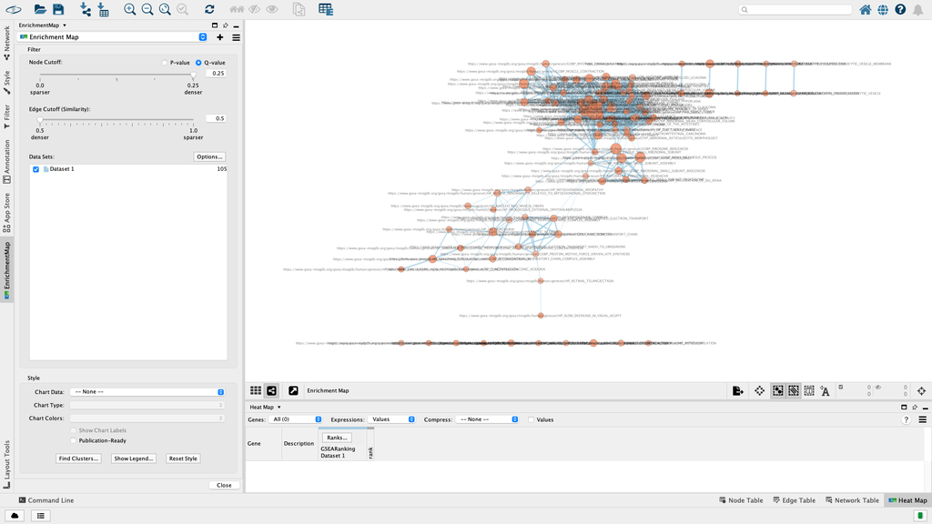

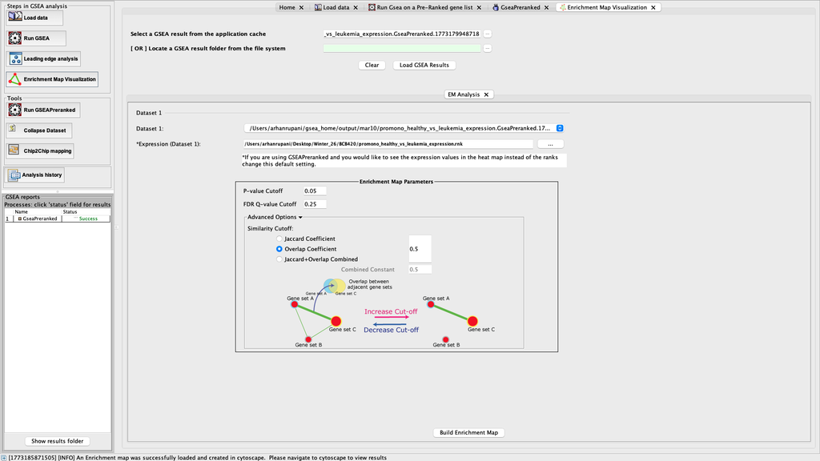

2. Annotate your network - what parameters did you use to annotate the network. If you are using the default parameters make sure to list them as well.

I used autoannotate (Kucera et al. 2016)to cluster and annotate the network. I used the parameters depicted in the figure which follows,

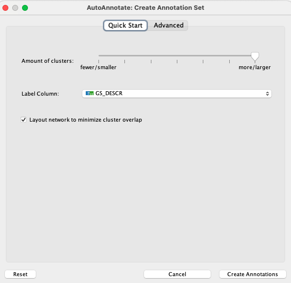

3. Make a publication ready figure - include this figure with proper legends in your notebook.

A publication ready figure is as follows:

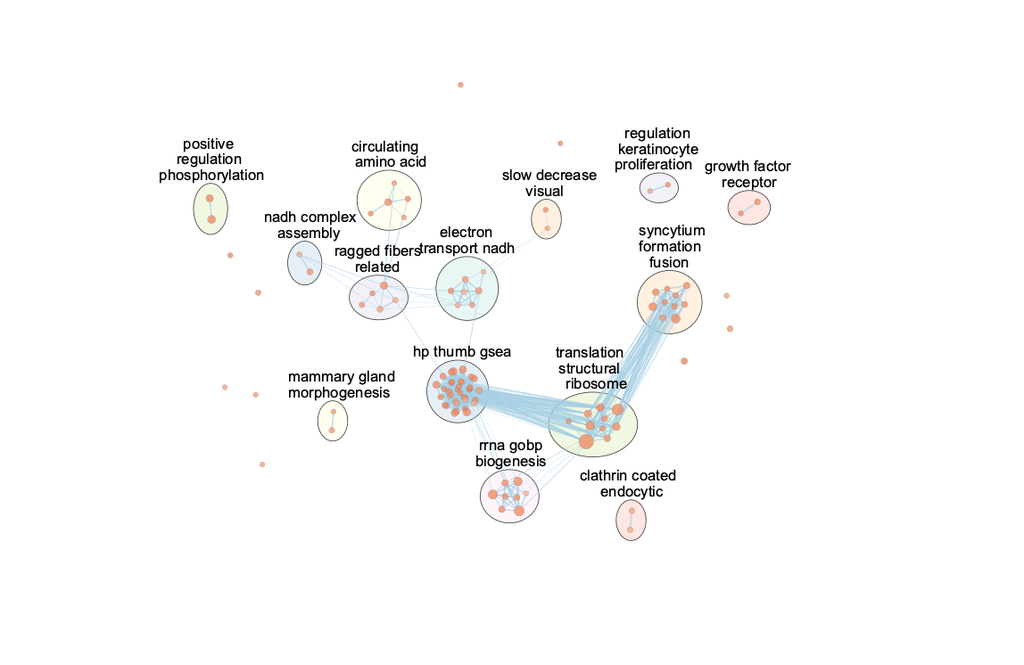

4. Collapse your network to a theme network. What are the major themes present in this analysis? Do they fit with the model? Are there any novel pathways or themes?

The following is the collapsed netwrk.

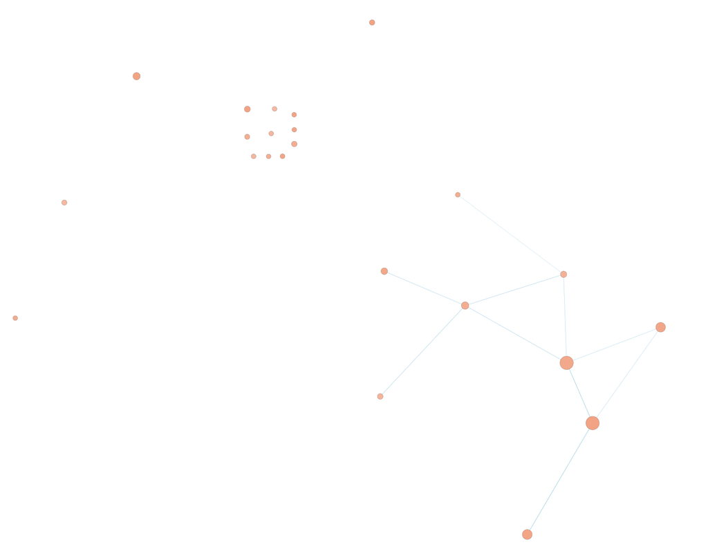

## 3.4 Interpretation and detailed view of results

Here I will relate my results back to the initial data and question.

1. Do the enrichment results support conclusions or mechanism discussed in the original paper? How do these results differ from the results you got from Assignment #2 thresholded methods

2. Can you find evidence, i.e. publications, to support some of the results that you see. How does this evidence support your result?

# 4 NOTE

# References

Chen, Xiaohe, Aimei Feng, Fan Chen, Jue Zeng, and Ming Chen. 2025. “Elucidating AML Ribosome Biogenesis Reshaping Prognostic Assessment and Immune Microenvironment Integrated Single-Cell and Bulk RNA Analysis.” *Frontiers in Immunology* 16 (November): 1644671. https://doi.org/10.3389/fimmu.2025.1644671.

Galen, Peter van, Volker Hovestadt, Marc H. Wadsworth Ii, et al. 2019. “Single-Cell RNA-Seq Reveals AML Hierarchies Relevant to Disease Progression and Immunity.” *Cell* 176 (6): 1265–1281.e24. https://doi.org/10.1016/j.cell.2019.01.031.

Gitareja, Kezia, Shalini S. Chelliah, Elaine Sanij, Shahneen Sandhu, Jian Kang, and Amit Khot. 2025. “Ribosome Biogenesis and Function in Cancer: From Mechanisms to Therapy.” *Cancers* 17 (15): 2534. https://doi.org/10.3390/cancers17152534.

Kolberg, Liis, Uku Raudvere, Ivan Kuzmin, Priit Adler, Jaak Vilo, and Hedi Peterson. 2023. “G:Profiler—Interoperable Web Service for Functional Enrichment Analysis and Gene Identifier Mapping (2023 Update).” *Nucleic Acids Research* 51 (W1): W207–12. https://doi.org/10.1093/nar/gkad347.

Kucera, Mike, Ruth Isserlin, Arkady Arkhangorodsky, and Gary D. Bader. 2016. *AutoAnnotate: A Cytoscape App for Summarizing Networks with Semantic Annotations*. F1000Research. https://doi.org/10.12688/f1000research.9090.1.

Merico, Daniele, Ruth Isserlin, Oliver Stueker, Andrew Emili, and Gary D. Bader. 2010. “Enrichment Map: A Network-Based Method for Gene-Set Enrichment Visualization and Interpretation.” *PLOS ONE* 5 (11): e13984. https://doi.org/10.1371/journal.pone.0013984.

Robichaud, Nathaniel, Nahum Sonenberg, Davide Ruggero, and Robert J. Schneider. 2019. “Translational Control in Cancer.” *Cold Spring Harbor Perspectives in Biology* 11 (7): a032896. https://doi.org/10.1101/cshperspect.a032896.

Shannon, Paul, Andrew Markiel, Owen Ozier, et al. 2003. “Cytoscape: A Software Environment for Integrated Models of Biomolecular Interaction Networks.” *Genome Research* 13 (11): 2498–504. https://doi.org/10.1101/gr.1239303.

Subramanian, Aravind, Pablo Tamayo, Vamsi K. Mootha, et al. 2005. “Gene Set Enrichment Analysis: A Knowledge-Based Approach for Interpreting Genome-Wide Expression Profiles.” *Proceedings of the National Academy of Sciences* 102 (43): 15545–50. https://doi.org/10.1073/pnas.0506580102.